# Introduction to Linear Regression

The Human Freedom Index is a report that attempts to summarize the idea of “freedom” through a bunch of different variables for many countries around the globe. It serves as a rough objective measure for the relationships between the different types of freedom - whether it’s political, religious, economical or personal freedom - and other social and economic circumstances. The Human Freedom Index is an annually co-published report by the Cato Institute, the Fraser Institute, and the Liberales Institut at the Friedrich Naumann Foundation for Freedom.

In this lab, you’ll be analyzing data from Human Freedom Index reports from 2008-2016. Your aim will be to summarize a few of the relationships within the data both graphically and numerically in order to find which variables can help tell a story about freedom.

# Getting Started

## Load packages

In this lab, you will explore and visualize the data using the **tidyverse** suite of packages. You will also use the **statsr** package to select a regression line that minimizes the sum of squared residuals.  
The data can be found in the **openintro** package, a companion package for OpenIntro resources.

Let’s load the packages.

```r
library(tidyverse)
library(openintro)
library(statsr)
## This requires that you have installed the statsr package!
```

# The data

The data we’re working with is in the openintro package and it’s called `hfi`, short for Human Freedom Index.

**1. What are the dimensions of the dataset?**

```r
## Code for question 1
```

```r
## Code for question 2
hfi_small <- hfi %>%
  select(pf_score, pf_expression_control, hf_score, year, region)
```

We can use the `drop_na()` function to get an idea of how many observations have missing data. The function looks row by row through the data to decide what rows should be kept. If there is an `NA` value in a row, that row is discarded. The result is a dataframe where there are no missing values for any of the variables.

**3** **part (a) Using the code below, how many rows in the `small_hfi` data have missing values?** **part (b) Use the `drop_na()` function to created another new dataframe named `hfi_small_clean` that **does not** contain any missing values.**

```r
drop_na(hfi) %>%
  dim()
```

```
## [1]   0 123
```

```r
hfi_small_clean <- drop_na(hfi_small)
```

**4. Plot the relationship between `pf_score` and `pf_expression_control`, using `pf_expression_control` as the predictor. Does the relationship look linear?**

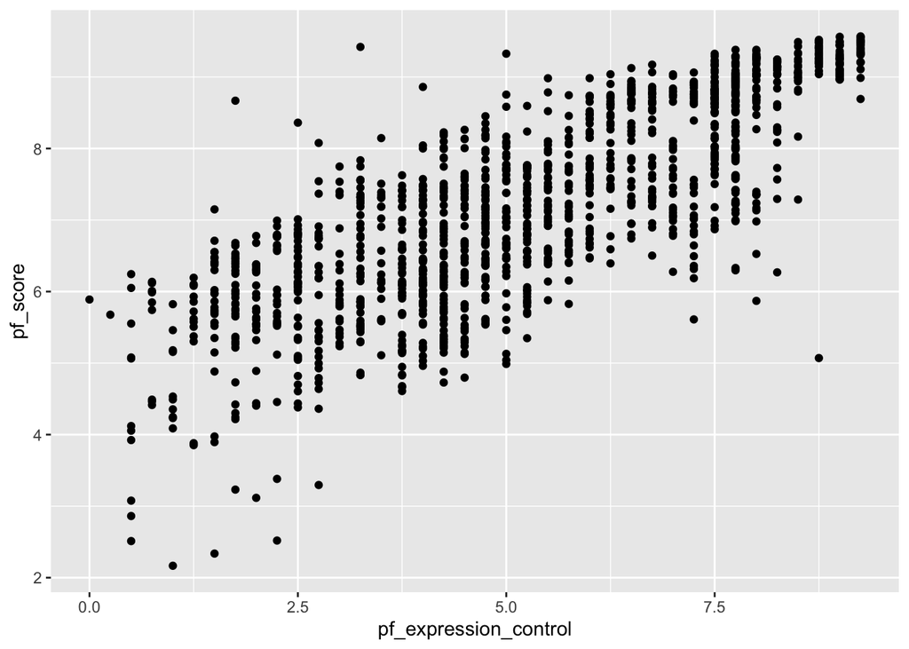

```r
## Code for question 2
hfi_small_clean %>%
  ggplot(aes(y = pf_score, x = pf_expression_control)) +
  geom_point()
```

**5. If you knew a country’s `pf_expression_control`, or its score out of 10, with 0 being the most, of political pressures and controls on media content, would you be comfortable using a linear model to predict the personal freedom score?**

**Note:** If the relationship looks linear, we can quantify the strength of the relationship with the correlation coefficient. Here, we use the `cor()` function to calculate the correlation between `pf_expression_control` and `pf_score`.

```r
hfi_small_clean %>%
  summarise(cor(pf_expression_control,
                pf_score))
```

```
## # A tibble: 1 x 1
##   `cor(pf_expression_control, pf_score)`
##                                    <dbl>
## 1                                  0.796
```

# Sum of squared residuals

In this section, you will use an interactive function to investigate what we mean by “sum of squared residuals”. You will need to run this function in your **console**, not in your RMarkdown document. Running the function also requires that the `hfi` dataset is loaded in your environment.

Think back to the way that we described the distribution of a single variable. Recall that we discussed characteristics such as center, spread, and shape. It’s also useful to be able to describe the relationship of two numerical variables, such as `pf_expression_control` and `pf_score` above.

**6. Looking at your plot from question 4, describe the relationship between pf_expression_control`and`pf_score`. Make sure to discuss the form, direction, and strength of the relationship as well as any unusual observations.**

Just as you’ve used the mean and standard deviation to summarize a single variable, you can summarize the relationship between these two variables by finding the line that best follows their association. Use the following interactive function to select the line that you think does the best job of going through the cloud of points.

```r
plot_ss(x = pf_expression_control, y = pf_score, data = hfi_small_clean)
```

After running this command, you’ll be prompted to click two points on the plot to define a line. Once you’ve done that, the line you specified will be shown in black and the residuals in blue. Recall that the residuals are the difference between the observed values and the values predicted by the line:

$$e_i = y_i - \hat{y}_i$$

The most common way to do linear regression is to select the line that minimizes the sum of squared residuals. To visualize the squared residuals, you can rerun the plot command and add the argument `showSquares = TRUE`. Where you saw the blue residual lines before, here you see yellow squares. The squares provide a visual representation of how each observation is contributing to the sum of squared residuals. Points closer to the line have smaller squares than points further from the line.

```r
plot_ss(x = pf_expression_control, y = pf_score, data = hfi_small_clean, showSquares = TRUE)
```

**Note:** The output from the `plot_ss()` function provides you with the slope and intercept of your line as well as the sum of squares.

**7. Using `plot_ss`, choose a line that does a good job of minimizing the sum of squares. Run the function several times. What was the smallest sum of squares that you got? How does it compare to your neighbors?**

# The Linear Model

It is rather cumbersome to try to get the correct least squares line, i.e. the line that minimizes the sum of squared residuals, through trial and error. Instead, you can use the `lm()` function in R to fit the linear model (a.k.a. regression line).

```r
pf_model <- lm(pf_score ~ pf_expression_control, data = hfi)
```

The first argument in the function `lm()` is a formula that takes the form `y ~ x`. In this context it can be read that we want to make a linear model of `pf_score` as a function of `pf_expression_control`. The second argument specifies that R should look in the `hfi` data frame to find the two variables.

**Note:** Piping **will not** work here, as the dataframe is not the first argument!

The output of `lm()` is an object that contains all of the information we need about the linear model that was just fit. We can access this information using the `summary()` function.

```r
summary(pf_model)
```

```
##
## Call:
## lm(formula = pf_score ~ pf_expression_control, data = hfi)
##
## Residuals:
##     Min      1Q  Median      3Q     Max
## -3.8467 -0.5704  0.1452  0.6066  3.2060
##
## Coefficients:
##                       Estimate Std. Error t value Pr(>|t|)
## (Intercept)            4.61707    0.05745   80.36   <2e-16 ***
## pf_expression_control  0.49143    0.01006   48.85   <2e-16 ***
## ---
## Signif. codes:  0 '***' 0.001 '**' 0.01 '*' 0.05 '.' 0.1 ' ' 1
##
## Residual standard error: 0.8318 on 1376 degrees of freedom
##   (80 observations deleted due to missingness)
## Multiple R-squared:  0.6342, Adjusted R-squared:  0.634
## F-statistic:  2386 on 1 and 1376 DF,  p-value: < 2.2e-16
```

Let’s consider this output piece by piece. First, the formula used to describe the model is shown at the top, in what’s displayed as the “Call”. After the formula you find the five-number summary of the residuals. The “Coefficients” table shown next is key; its first column displays the linear model’s y-intercept and the coefficient of `pf_expression_control`. With this table, we can write down the least squares regression line for the linear model:

$$\hat{pf\_score} = 4.61707 + 0.49143 \times pf\_expression\_control$$
This equation tells us two things: 1. For countries with a `pf_expression_control` of 0 (those with the largest amount of political pressure on media content), we expect their mean personal freedom score to be 4.61707. 2. For every 1 unit increase in `pf_expression_control`, we expect a country’s mean personal freedom score to increase 0.49143 units. One last piece of information we will discuss from the summary output is the Multiple R-squared, or more simply, $R^2$. The $R^2$ value represents the proportion of variability in the response variable that is explained by the explanatory variable. For this model, 63.42% of the variability in `pf_score` is explained by `pf_expression_control`.

**8. Fit a new model that uses `pf_expression_control` to predict `hf_score`, or the total human freedom score. Using the estimates from the R output, write the equation of the regression line. What does the slope tell us in the context of the relationship between human freedom and the amount of political pressure on media content?**

```r
## Code for question 8
hf_model <- lm(hf_score ~ pf_expression_control, data = hfi_small_clean)
summary(hf_model)
```

```
##
## Call:
## lm(formula = hf_score ~ pf_expression_control, data = hfi_small_clean)
##
## Residuals:
##     Min      1Q  Median      3Q     Max
## -2.6198 -0.4908  0.1031  0.4703  2.2933
##
## Coefficients:
##                       Estimate Std. Error t value Pr(>|t|)
## (Intercept)           5.153687   0.046070  111.87   <2e-16 ***
## pf_expression_control 0.349862   0.008067   43.37   <2e-16 ***
## ---
## Signif. codes:  0 '***' 0.001 '**' 0.01 '*' 0.05 '.' 0.1 ' ' 1
##
## Residual standard error: 0.667 on 1376 degrees of freedom
## Multiple R-squared:  0.5775, Adjusted R-squared:  0.5772
## F-statistic:  1881 on 1 and 1376 DF,  p-value: < 2.2e-16
```

# Prediction and Prediction Errors

Let’s create a scatterplot with the least squares line for `pf_model` laid on top.

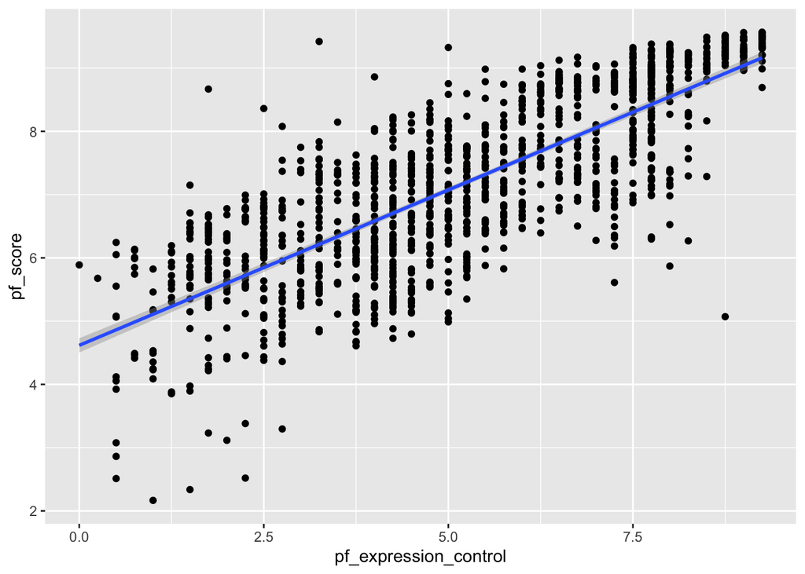

```r
hfi %>%
  ggplot(aes(x = pf_expression_control, y = pf_score)) +
  geom_point() +
  geom_smooth(method = "lm")
```

Here, we are literally adding a layer on top of our plot. `geom_smooth` creates the line by fitting a linear model. It can also show us the standard error `se` associated with our line, which is a bit difficult to see.

This regression line can be used to predict $y$ at any value of $x$. When predictions are made for values of $x$ that are beyond the range of the observed data, it is referred to as *extrapolation* and is usually not recommended. However, predictions made within the range of the data are more reliable. These predictions in the data are used to compute the residuals.

**9. If someone saw the least squares regression line and not the actual data, how would they predict a country’s personal freedom score if the country had a 6.7 rating for `pf_expression_control`? If the Is this an overestimate or an underestimate, and by how much? In other words, what is the residual for this prediction?**

# Model Diagnostics

To assess whether the linear model is reliable, we need to check for (1) linearity, (2) nearly normal residuals, and (3) constant variability.

**Linearity**: You already checked if the relationship between `pf_score` and `pf_expression_control` is linear using a scatterplot. We should also verify this condition with a plot of the residuals vs. fitted (predicted) values.

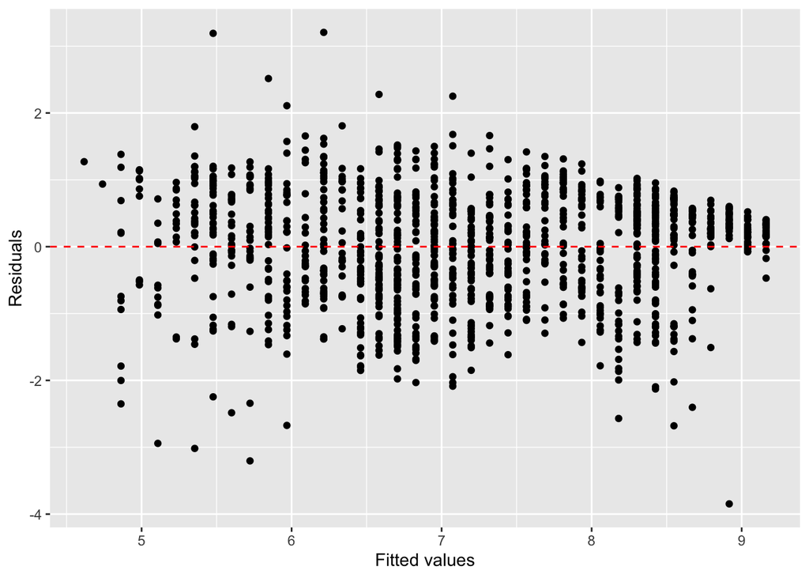

```r
ggplot(data = pf_model, aes(x = .fitted, y = .resid)) +
  geom_point() +
  geom_hline(yintercept = 0, linetype = "dashed", color = "red") +
  xlab("Fitted values") +
  ylab("Residuals")
```

Notice here that `pf_model` can also serve as a data set because stored within it are the fitted values ($\hat{y}$) and the residuals. Also note that we’re getting fancy with the code here. After creating the scatterplot on the first layer (first line of code), we overlay a horizontal dashed red line at $y = 0$ (to help us check whether residuals are distributed around 0), and we also rename the axis labels to be more informative.

**10. Is there any apparent pattern in the residuals plot? What does this indicate about the linearity of the relationship between the two variables?**

**Nearly normal residuals**: To check this condition, we can look at a histogram of the residuals from the model.

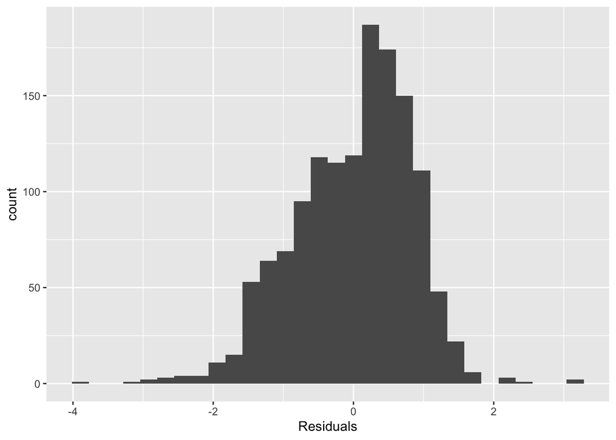

```r
ggplot(data = pf_model, aes(x = .resid)) +
  geom_histogram(bins = 30) +
  xlab("Residuals")
```

**11. Based on the histogram, does the nearly normal residuals condition appear to be violated? Why or why not?**

**Constant variability**:

**12. Based on the residuals vs. fitted plot, does the constant variability condition appear to be violated? Why or why not?**